# Paleta de colores

## Selección del modelo

Considerando los algoritmos que hemos trabajado durante el curso, y el objetivo del proyecto, las opciones se reducen a algoritmos que permitan realizar agrupación dura (hard-clustering), pues una suave (soft-clustering) tiene el objetivo de asignar valores probabilísticos a los pixeles y su resultado no sería ideal para la paleta de colores. Dentro de los agrupadores hard-clustering podemos pensar en k-means y DBSCAN, de acuerdo a la [documentación](https://scikit-learn.org/stable/modules/generated/sklearn.cluster.DBSCAN.html), DBSCAN no puede ser considerado para esta tarea, pues este algoritmo no garantiza una grupación completa de los píxeles al tener la posibilidad de considerar el "ruido" de la imagen, donde se podría dejar fuera de los clusters aquellos pixeles de ruido.

Dentro de k-means el número de clusters `k` no se fija de inmediato, esta se valida para cada imagen con métricas de agrupación, ya que la cantidad de colores dominantes varía según la complejidad de cada obra.

```python
%pip install -q --upgrade opencv-python-headless numpy matplotlib scikit-learn
```

[output not shown]

## Importar librerías

Importamos las librerías que vamos a utilizar en el proyecto

```python
import os
import textwrap
import cv2
import numpy as np
import pandas as pd
from matplotlib import pyplot as plt
from matplotlib.colors import rgb2hex

from sklearn.cluster import KMeans
from sklearn.manifold import TSNE
from sklearn.metrics import (
    silhouette_score,
    calinski_harabasz_score,
    davies_bouldin_score
)
from sklearn.pipeline import Pipeline
from sklearn.preprocessing import FunctionTransformer
```

## Constantes

Definimos las constantes que vamos a estar utilizando durante todo el proyecto. Como el random_state para mantener consistencia, la ruta de las imágenes, los valores k posibles para el modelo, etc.

```python
STATE = 42
IMAGES_PATH = 'data/images/'
K_VALUES = range(2, 15)

SAMPLE_SIZE = 50_000
SILHOUETTE_SIZE = 8000
TSNE_SAMPLE_SIZE = 3000

ESTIMATOR = 'kmeans'
N_INIT = 10
MAX_ITER = 300
BATCH_SIZE = 4096
```

## Función para cargar la imagen

Con estas funciones vamos a poder cargar todas las imágenes y obtener sus nombres, utilizamos el método `sort` para mantener una consistencia en el orden de los imports en cada ejecución

```python
def load_image(route:str):
    # Load image
    image_bgr = cv2.imread(route)

    if image_bgr is None:
        raise ValueError(f'OpenCV no pudo leer {route}')

    if image_bgr.ndim != 3:
        raise ValueError(f'Formato no soportado: {image_bgr.shape}')

    image_rgb = cv2.cvtColor(image_bgr, cv2.COLOR_BGR2RGB)

    return image_rgb

def load_images(root_path: str):
    img_files_list = sorted(os.listdir(root_path))

    img_list = list()
    img_names = list()

    for img_file in img_files_list:
        img_path = os.path.join(root_path, img_file)
        image_rgb = load_image(img_path)

        img_list.append(image_rgb)
        img_names.append(os.path.splitext(img_file)[0])

    return img_list, img_names
```

## Imagenes seleccionadas

Escribimos una función que nos pueda ser útil cada vez que queramos graficar una lista de imágenes.

```python
def plot_img_list(img_list, n_cols: int = 4, titles=None, suptitle: str = 'Imagenes seleccionadas'):
    # Image title
    title_wrap = 24
    title_fontsize = 9
    row_height = 4.5

    # Create the plot
    n_imgs = len(img_list)
    n_rows = -(-n_imgs // n_cols)
    fig = plt.figure(figsize=(20, row_height * n_rows))

    for i, raw_image in enumerate(img_list):
        ax = fig.add_subplot(n_rows, n_cols, i + 1)

        title = titles[i] if titles else f'Imagen #{i + 1}'
        wrapped_title = '\n'.join(textwrap.wrap(title, width=title_wrap))
        ax.set_title(wrapped_title, fontsize=title_fontsize)

        ax.imshow(raw_image)
        ax.axis('off')

    fig.suptitle(suptitle)
    plt.tight_layout()
    plt.show()
```

En este caso vamos a visualizar todas las imágenes que seleccionamos para el proyecto, en total son 10. Los títulos de cada imagen es obtenido de su ruta, se le da formato al texto para que sea más legible.

[figure not shown]

```python
raw_images, image_names = load_images(IMAGES_PATH)
raw_images_titles = [name.replace('_', ' - ').replace('-', ' ') for name in image_names]
plot_img_list(raw_images, titles=raw_images_titles)
```

## Motivación de la selección

Se seleccionaron estas imágenes que representan distintos estilos artísticos (por ejemplo: Impresionismo, Primitivismo, Modernismo, entre otras) para poner a prueba la generación de paletas con distintos rangos de colores dominantes con paletas suaves y difuminadas, colores planos, tonos más oscuros e incluso obras en escalas de grises.

## Pipeline de las imagenes

Este pipeline será utilizado para transformar las imágenes en matrices de píxeles más manejables, realizando `flat` sobre los píxeles para pasar de una matriz (alto, ancho, 3) a una de tipo (alto*ancho, 3) reduciendo sus dimensiones; además se normalizan los valores de RGB para que queden en rangos de 0 a 1.

Esta normalización no cambia el resultado del agrupamiento, se hace únicamente para que los centroides queden en el rango esperado por `rgb2hex` y las funciones de color de matplotlib usadas más adelante para construir la paleta.

Definimos una función para obtener el modelo K-Means con una configuraciíon estándar y donde únicamente variamos el valor `k`.

```python
def get_model(k):
    return KMeans(
        n_clusters=k,
        init='k-means++',
        n_init=N_INIT,
        max_iter=MAX_ITER,
        random_state=STATE
    )
```

Y definimos también el pipeline para preparación de las imágenes con las operaciones de `flatten` y `normalize`.

Además se agrega una función `sample_pixels` para obtener sub-muestras de los pixeles de una imagen, esto es utilizado para reducir la dimensionalidad de las imágenes y mejorar los tiempos de entrenamiento. Estamos seleccionando filas aleatorias de cada imagen y la cuenta de esas filas debe ser menor a `sample_size`.

```python
def flatten_pixels(img):
    return img.reshape((-1, 3))

def normalize_pixels(fn_img):
    return fn_img / 255.0

pipeline_steps = [
    ('flatten', FunctionTransformer(flatten_pixels, validate=False)),
    ('normalize', FunctionTransformer(normalize_pixels, validate=False))
]

image_prep_pipeline = Pipeline(pipeline_steps)

def sample_pixels(img, sample_size, rng):
    n_pixels = img.shape[0]
    if n_pixels <= sample_size:
        return pixels, np.arange(n_pixels)

    ind = rng.choice(n_pixels, size=sample_size, replace=False)
    return img[ind], ind
```

## Muestreo

```python
def find_best_k(fn_img, k_values=K_VALUES, sample_size=SAMPLE_SIZE, silhouette_size=SILHOUETTE_SIZE, random_state=STATE):
    rng = np.random.default_rng(random_state)
    fit_sample, _ = sample_pixels(fn_img, sample_size, rng)
    _, silhouette_ind = sample_pixels(fit_sample, silhouette_size, rng)

    rows = []
    for k in k_values:
        model = get_model(k)
        model.fit(fit_sample)
        labels = model.labels_

        rows.append({
            'k': k,
            'silhouette': silhouette_score(fit_sample[silhouette_ind], labels[silhouette_ind]),
            'calinski_harabasz': calinski_harabasz_score(fit_sample, labels),
            'davies_bouldin': davies_bouldin_score(fit_sample, labels)
        })

    return pd.DataFrame(rows), fit_sample
```

## Selección de clusters

El número de colores dominantes no es el mismo para las imágenes en escalas de grises que para las imágenes a color o imágenes con colores planos y retratos más detallados. Buscamos el mejor `k` entre los valores del rango de `K_VALUES`. Las métricas utilizadas son:

- **Silhouette**: donde un valor más cercano a 1 es mejor y el peor es cercano a -1, esto comprueba qué tan separado está un pixel de los clusters vecinos.
- **Calinski-Harabasz** y **Davies-Bouldin**: Utilizados para corroborar la elección de silhouette, con calinski-harabasz un valor mayor es mejor, mientras que con davies-bouldin un valor menor es mejor.

Definimos esta función para realizar el entrenamiento del modelo, llamando la función para encontrar el mejor `k` y aplicando el criterio del consenso de rangos entre las 3 métricas para seleccionar el mejor `k`. Con este `k` entrenamos el modelo definitivo y construimos un resumen con las opciones de `k` por cada métrica, el que se seleccionó y el valor de cada métrica en ese k.

```python
def get_metrics_report(metrics):
    max_silhouette = int(metrics.loc[metrics['silhouette'].idxmax(), 'k'])
    max_ch = int(metrics.loc[metrics['calinski_harabasz'].idxmax(), 'k'])
    min_db = int(metrics.loc[metrics['davies_bouldin'].idxmin(), 'k'])

    metrics['ranked_silhouette'] = metrics['silhouette'].rank(ascending=False)
    metrics['ranked_calinski_harabasz'] = metrics['calinski_harabasz'].rank(ascending=False)
    metrics['ranked_davies_bouldin'] = metrics['davies_bouldin'].rank(ascending=True)

    metrics['score'] = (
        metrics['ranked_silhouette'] +
        metrics['ranked_calinski_harabasz'] +
        metrics['ranked_davies_bouldin']
    )

    best_row = metrics.sort_values(by=['score', 'k']).iloc[0]
    best_k = int(best_row['k'])

    best_silhouette = best_row['silhouette']
    best_ch = best_row['calinski_harabasz']
    best_db = best_row['davies_bouldin']

    report = {
        'k (Silhouette)': max_silhouette,
        'k (Calinski-Harabasz)': max_ch,
        'k (Davies-Bouldin)': min_db,
        'Selected K': best_k,
        'Silhouette at K': best_silhouette,
        'Calinski-Harabasz at K': best_ch,
        'Davies-Bouldin at K': best_db
    }

    return best_k, report

def train_model(fn_img, title=''):
    metrics, fit_sample = find_best_k(fn_img)

    best_k, report = get_metrics_report(metrics)
    print(f'[{title}] k seleccionado: {best_k}')

    model = get_model(best_k)
    print(f'[{title}] Training model...')
    model.fit(fit_sample)

    summary = {
        'Image': title,
        **report
    }

    return model, summary
```

Esta función tiene la finalidad de generar la imagen segmentada, utilizando el modelo entrenado, se predicen los clusters de la imagen original (normalizada y aplanada), se toman los labels y los centros de esta predicción para construír la nueva imagen donde se aprecia la segmentación en formato RGB y con sus dimensiones con la forma de la imagen original para ser graficada correctamente.

```python
def restore_img(fn_img, img_model, img_shape):
    labels = img_model.predict(fn_img)
    centers = img_model.cluster_centers_

    img_segmented_denormalized = centers[labels] * 255
    img_segmented_orig_shape = img_segmented_denormalized.reshape(img_shape)

    return img_segmented_orig_shape.astype(np.uint8)

def compute_cluster_proportions(fn_img, img_model):
    labels = img_model.predict(fn_img)
    counts = np.bincount(labels, minlength=img_model.n_clusters)
    return counts / counts.sum()
```

## Paleta de colores

Generamos una imagen con las franjas verticales que indican cada color dominante de la imagen, basándonos en los centroides del modelo.

El ancho de cada franja es proporcional a la fracción de pixeles que ese color representa en la imagen. Las franjas se ordenan de mayor a menor proporción, y para evitar que colores poco frecuentes queden con una franja muy angosta se definió un ancho mínimo a las franjas.

Al pié de cada franja se agregan textos con el color en formato Hexadecimal para identificar con mayor precisión cada color.

```python
def generate_palette(img_model, proportions, bar_height=500, label_height=80, max_width=1000, min_bar_width=120):
    centers = img_model.cluster_centers_
    centers_count = centers.shape[0]

    # Order proportions
    order = np.argsort(proportions)[::-1]
    centers = centers[order]
    proportions = np.asarray(proportions)[order]

    # Hex colors
    hexa = [rgb2hex(centers[i, :]) for i in range(centers_count)]
    # RGB colors
    rgb = (centers * 255).astype(np.uint8)

    # Palette image dimensions
    bar_widths = [max(
        min_bar_width,
        int(round(p * max_width))
    ) for p in proportions]
    total_width = sum(bar_widths)

    im_height = bar_height + label_height
    im_dimensions = (im_height, total_width, 3)

    # Create base image for palette
    palette = np.full(im_dimensions, 255, dtype=np.uint8)

    # Define font for the palette color labels
    font = cv2.FONT_HERSHEY_SIMPLEX
    font_scale = 0.6
    font_thickness = 2

    x_start = 0
    for color, width, label_hex in zip(rgb, bar_widths, hexa):
        x_end = x_start + width
        palette[:bar_height, x_start:x_end] = color

        label = label_hex.upper()

        (text_w, text_h), _ = cv2.getTextSize(label, font, font_scale, font_thickness)

        text_x = x_start + (width - text_w) // 2
        text_y = bar_height + (label_height + text_h) // 2
        text_pos = (text_x, text_y)
        text_rgb = (0, 0, 0)

        # Add text at the bottom of the color bar
        cv2.putText(palette, label, text_pos, font, font_scale, text_rgb, font_thickness, cv2.LINE_AA)

        x_start = x_end

    return palette
```

## Distribución t-SNE

Realizamos la visualización de cómo se distribuyen los colores aplicando t-SNE sobre los 3 canales de RGB de una muestra de pixeles. Este gráfico muestra las relaciones de cercanía entre los puntos (pixeles con colores similares quedan cerca).

```python
def plot_color_distribution(fn_img, img_model, title=''):
    rng = np.random.default_rng(STATE)
    sample, _ = sample_pixels(fn_img, TSNE_SAMPLE_SIZE, rng)

    labels = img_model.predict(sample)
    centers = img_model.cluster_centers_

    tsne = TSNE(n_components=2, random_state=STATE, perplexity=30, init='pca')
    embed = tsne.fit_transform(sample)
    point_colors = [rgb2hex(centers[label]) for label in labels]

    fig, ax = plt.subplots(figsize=(7, 6))
    ax.scatter(embed[:, 0], embed[:, 1], c=point_colors, s=6, edgecolors='none')

    for clust_id in range(centers.shape[0]):
        mask = labels == clust_id
        if mask.any():
            cx = embed[mask, 0].mean()
            cy = embed[mask, 1].mean()
            ax.text(
                cx, cy, rgb2hex(centers[clust_id]).upper(),
                fontdict={'weight': 'bold', 'size': 10}, ha='center', va='center',
                bbox=dict(boxstyle='round', facecolor='white', edgecolor='none')
            )

    ax.set_title(f'Distribucion de colores (t-SNE) - {title}')
    ax.set_xlabel('t-SNE 1')
    ax.set_ylabel('t-SNE 2')
    plt.tight_layout()
    plt.show()
```

Función principal donde se define el paso a paso para procesar las imágenes: Se prepara cada imagen con el pipeline, se entrena el modelo con el `k` elegido, se calculan las proporciones de cada color para la paleta, se genera la imagen segmentada, se genera la paleta y la distribución t-SNE. Además de una lista con las imágenes de resultado, se devuelve una tabla resumen por imagen (`k` por cada métrica, `k` seleccionado, valor de cada métrica con el `k` seleccionado).

```python
def segment_images(img_list, titles=None):
    print("="*40)
    print(f'STARTING IMAGE SEGMENTATION\nImages to segment: {len(img_list)}')
    print("="*40)

    finished_img = []
    labels = []
    summaries = []

    for i, img in enumerate(img_list):
        title = titles[i] if titles else f'Imagen #{i + 1}'

        fn_img = image_prep_pipeline.fit_transform(img)
        trained_model, summary = train_model(fn_img, title=title)
        proportions = compute_cluster_proportions(fn_img, trained_model)
        segmented_img = restore_img(fn_img, trained_model, img.shape)
        palette = generate_palette(trained_model, proportions)
        plot_color_distribution(fn_img, trained_model, title=title)

        finished_img.extend([img, segmented_img, palette])
        labels.extend([
            f'{title} - Original',
            f'{title} - Segmentada (k={trained_model.n_clusters})',
            f'{title} - Paleta'
        ])
        summaries.append(summary)

    print("="*40)
    print("FINISHED IMAGE SEGMENTATION")
    print("="*40)

    summary_df = pd.DataFrame(summaries)
    return finished_img, labels, summary_df
```

Con todo preparado, podemos enviar nuestras imágenes. Para ello seleccionamos 2 imágenes del conjunto, seleccionamos de la lista de nombres los primeros dos elementos de la lista, calculamos el índice de estos nombres los cuales deben coincidir con el orden de la lista de imágenes (pues fueron ordenados anteriormente), con el índice seleccionamos las imágenes correspondientes de la lista de imágenes y las enviamos al método de `segment_images` para ejecutar todo el flujo.

```
========================================
STARTING IMAGE SEGMENTATION
Images to segment: 2
========================================
[albert-gleizes_portrait-of-igor-stravinsky-1914] k seleccionado: 7
[albert-gleizes_portrait-of-igor-stravinsky-1914] Training model...
```

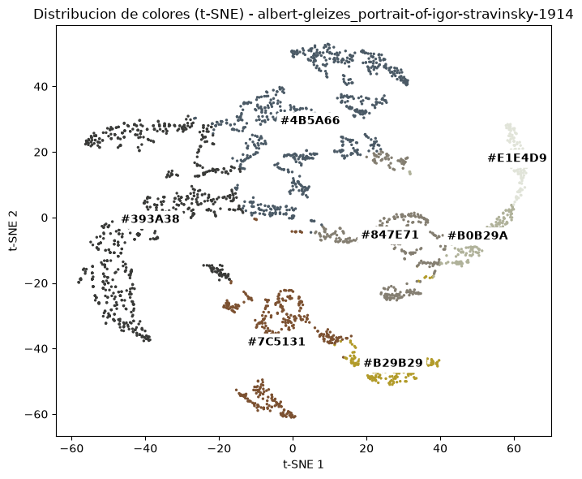

```
[alfred-sisley_two-women-walking-along-the-riverbank-1885] k seleccionado: 3
[alfred-sisley_two-women-walking-along-the-riverbank-1885] Training model...
```

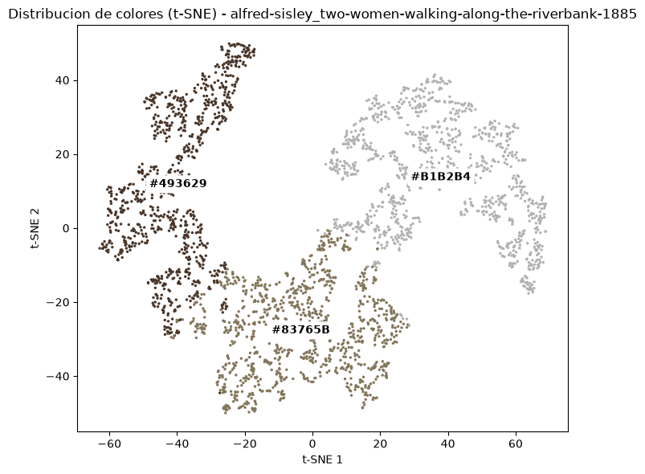

```
========================================
FINISHED IMAGE SEGMENTATION
========================================
```

|  | Image | k (Silhouette) | k (Calinski-Harabasz) | k (Davies-Bouldin) | Selected K | Silhouette at K | Calinski-Harabasz at K | Davies-Bouldin at K |
| --- | --- | --- | --- | --- | --- | --- | --- | --- |
| 0 | albert-gleizes_portrait-of-igor-stravinsky-1914 | 7 | 8 | 7 | 7 | 0.537539 | 96259.283699 | 0.590678 |
| 1 | alfred-sisley_two-women-walking-along-the-rive... | 2 | 3 | 2 | 3 | 0.554665 | 169065.669799 | 0.615417 |

```python
demo_names = image_names[:2]
demo_ind = [image_names.index(name) for name in demo_names]
demo_images = [raw_images[i] for i in demo_ind]

result, result_labels, summary_df = segment_images(demo_images, titles=demo_names)
summary_df
```

Por último graficamos los resultados, donde por cada imagen original se debe ver graficado: la imagen original, la imagen segmentada y la paleta de colores extraída.

[figure not shown]

```python
plot_img_list(result, n_cols=3, titles=result_labels, suptitle='Resultado de segmentacion y paleta')
```

## Set completo

Ahora que verificamos que nuestra implementación funciona, vamos a correr el flujo con el set completo de imágenes (10 en total)

```
========================================
STARTING IMAGE SEGMENTATION
Images to segment: 10
========================================
[albert-gleizes_portrait-of-igor-stravinsky-1914] k seleccionado: 7
[albert-gleizes_portrait-of-igor-stravinsky-1914] Training model...
```

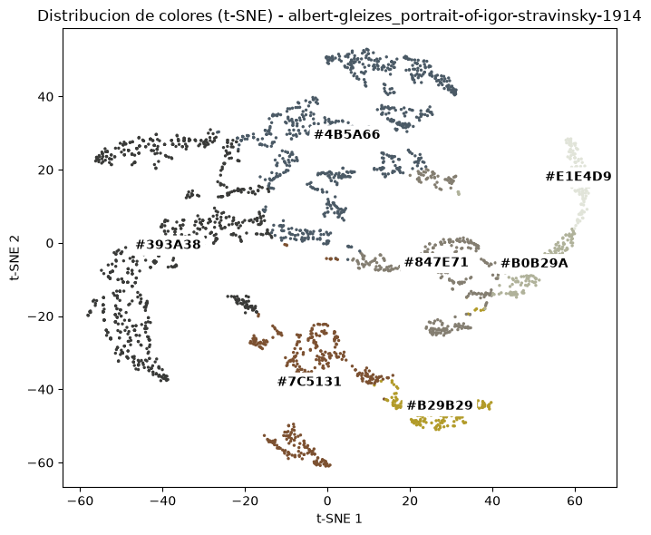

```
[alfred-sisley_two-women-walking-along-the-riverbank-1885] k seleccionado: 3
[alfred-sisley_two-women-walking-along-the-riverbank-1885] Training model...
```

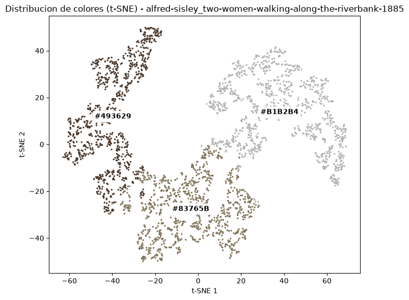

```
[franz-kline_mycenae-1958] k seleccionado: 3
[franz-kline_mycenae-1958] Training model...
```

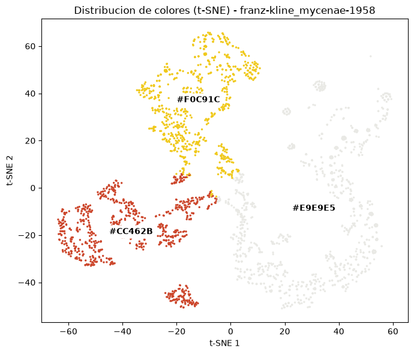

```
[hans-holbein-the-younger_model-of-the-dance-house-in-basel] k seleccionado: 2
[hans-holbein-the-younger_model-of-the-dance-house-in-basel] Training model...
```

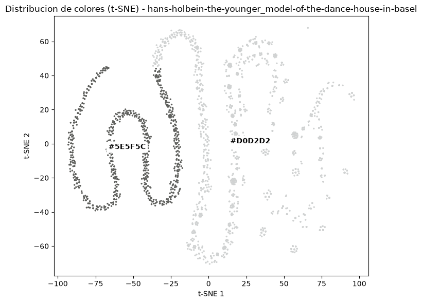

```
[ipolit-strambu_cochet-rie] k seleccionado: 5
[ipolit-strambu_cochet-rie] Training model...
```

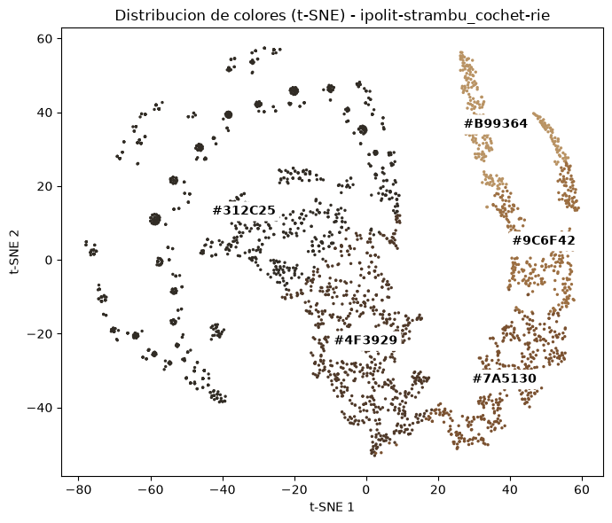

```
[isaac-levitan_by-the-riverside-1] k seleccionado: 2
[isaac-levitan_by-the-riverside-1] Training model...
```

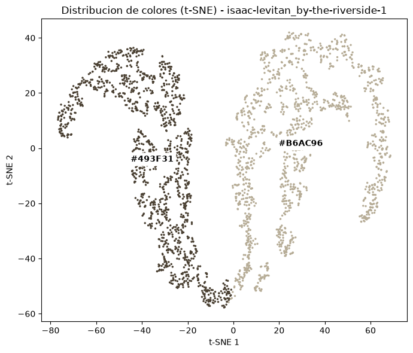

```
[niko-pirosmani_antlered-deer] k seleccionado: 2
[niko-pirosmani_antlered-deer] Training model...
```

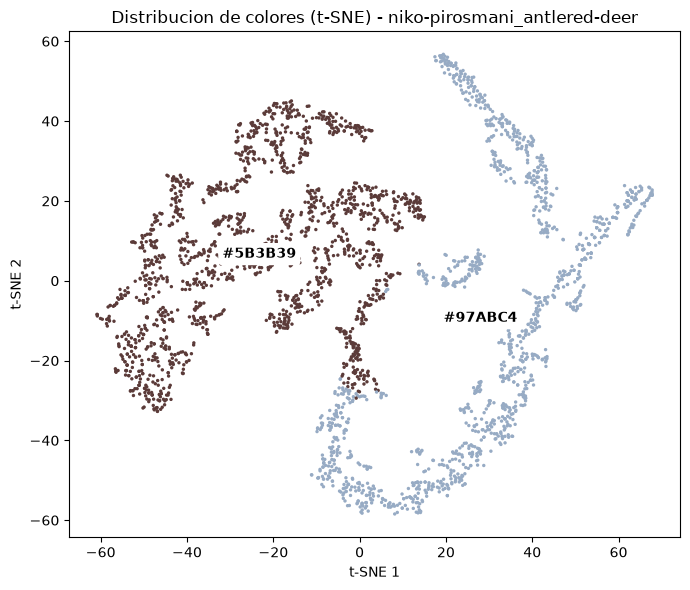

```
[paolo-veronese_boy-with-a-greyhound] k seleccionado: 5
[paolo-veronese_boy-with-a-greyhound] Training model...
```

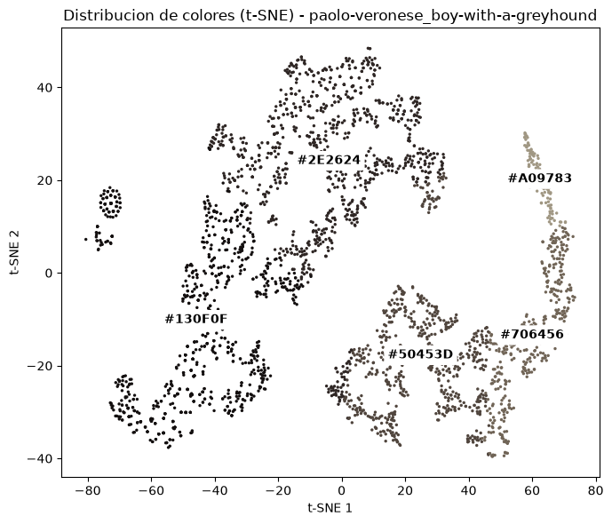

```
[sergey-solomko_two-sketches-of-costumes] k seleccionado: 2
[sergey-solomko_two-sketches-of-costumes] Training model...
```

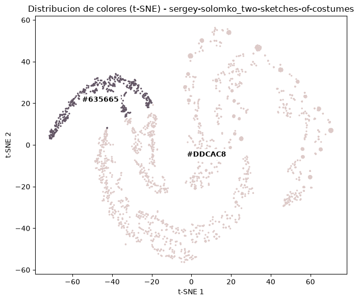

```
[vasily-polenov_oyat-river] k seleccionado: 2
[vasily-polenov_oyat-river] Training model...
```

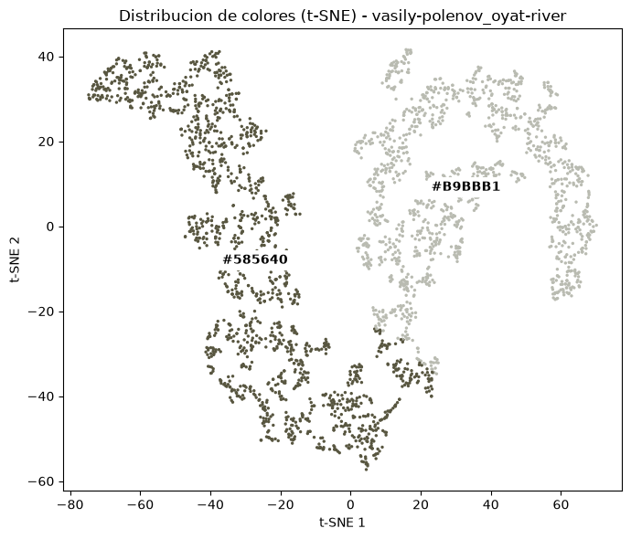

```
========================================
FINISHED IMAGE SEGMENTATION
========================================
```

|  | Image | k (Silhouette) | k (Calinski-Harabasz) | k (Davies-Bouldin) | Selected K | Silhouette at K | Calinski-Harabasz at K | Davies-Bouldin at K |
| --- | --- | --- | --- | --- | --- | --- | --- | --- |
| 0 | albert-gleizes_portrait-of-igor-stravinsky-1914 | 7 | 8 | 7 | 7 | 0.537539 | 96259.283699 | 0.590678 |
| 1 | alfred-sisley_two-women-walking-along-the-rive... | 2 | 3 | 2 | 3 | 0.554665 | 169065.669799 | 0.615417 |
| 2 | franz-kline_mycenae-1958 | 3 | 6 | 3 | 3 | 0.803330 | 420867.018746 | 0.282039 |
| 3 | hans-holbein-the-younger_model-of-the-dance-ho... | 2 | 14 | 2 | 2 | 0.678141 | 179223.239831 | 0.448512 |
| 4 | ipolit-strambu_cochet-rie | 2 | 7 | 2 | 5 | 0.508422 | 204192.863439 | 0.656574 |
| 5 | isaac-levitan_by-the-riverside-1 | 2 | 10 | 2 | 2 | 0.748627 | 303967.739955 | 0.337409 |
| 6 | niko-pirosmani_antlered-deer | 2 | 5 | 2 | 2 | 0.643023 | 148592.169434 | 0.508134 |
| 7 | paolo-veronese_boy-with-a-greyhound | 2 | 7 | 2 | 5 | 0.465865 | 121086.709183 | 0.681074 |
| 8 | sergey-solomko_two-sketches-of-costumes | 2 | 13 | 2 | 2 | 0.739037 | 121131.142005 | 0.488433 |
| 9 | vasily-polenov_oyat-river | 2 | 2 | 2 | 2 | 0.698277 | 220964.920676 | 0.407749 |

```python
result, result_labels, summary_df = segment_images(raw_images, titles=image_names)
summary_df
```

[figure not shown]

```python
plot_img_list(result, n_cols=3, titles=result_labels, suptitle='Resultado de segmentacion y paleta')
```